# Introduction to Open Data Science

University of Helsinki, spring 2017

- Tuomo Nieminen and Emma Kämäräinen with
- Adjunct professor Kimmo Vehkalahti

Powered by Rpresentation. The code for this presentation is [here](https://raw.githubusercontent.com/TuomoNieminen/Helsinki-Open-Data-Science/master/docs/index.Rpres)

From data wrangling to exploration and modelling

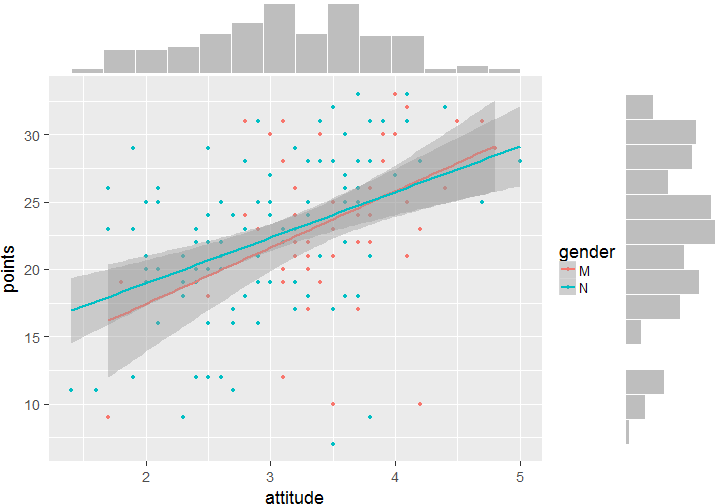

### Contents

1. Regression and model validation
2. Logistic regression
3. Clustering and classification
4. Dimensionality reduction techniques

## Linear regression and model validation

For IODS by Tuomo Nieminen

Powered by Rpresentation. The code for this presentation is [here.](https://raw.githubusercontent.com/TuomoNieminen/Helsinki-Open-Data-Science/master/docs/regression.Rpres)

### Linear regression models

Simple regression

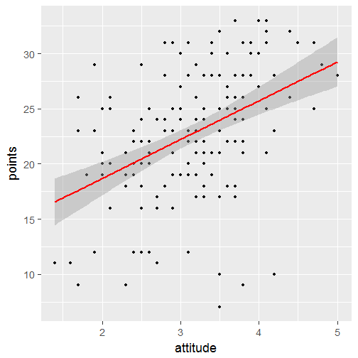

Multiple regression

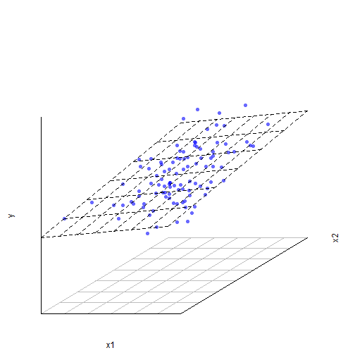

### What is a statistical model?

A statistical model:

- Embodies a set of assumptions and describes the generation of a sample from a population
- Represents the data generating process
- The uncertainty related to a sample of data is described using probability distributions

### Linear regression models

Linear regression is an approach for modeling the relationship between a dependent variable \( \boldsymbol{y} \) and one or more explanatory variables \( \boldsymbol{X} \).

There are many applications for linear models such as

- Prediction or forecasting
- Quantifying the strength of the relationship between \( \boldsymbol{y} \) and \( \boldsymbol{x} \)

### Simple regression

In a simple case, the model includes one explanatory variable \( \boldsymbol{x} \)

\( \boldsymbol{y} = \alpha + \beta \boldsymbol{x} + \boldsymbol{\epsilon} \)

R:  
`lm(y ~ x)`

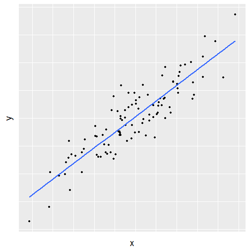

### Multiple regression

The model can also include more than one explanatory variable

\[ \boldsymbol{y} = \alpha + \beta_1 \boldsymbol{x}_1 + \beta_2 \boldsymbol{x}_2 + \boldsymbol{\epsilon} \]

R:  
`lm(y ~ x1 + x2)`

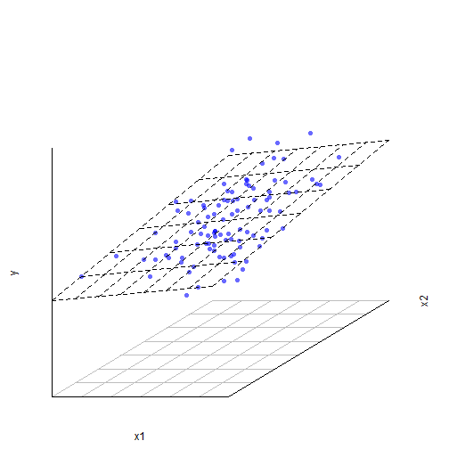

### Assumptions of linear regression models

In linear regression, it is assumed that the relationship between the target variable \( \boldsymbol{y} \) and the parameters (\( \alpha \), \( \boldsymbol{\beta} \)) is *linear*:

\[ \boldsymbol{y} = \boldsymbol{\alpha} + \boldsymbol{X} \boldsymbol{\beta} + \boldsymbol{\epsilon} \]

- The goal is to estimate the parameters \( \alpha \) and \( \boldsymbol{\beta} \), which describe the relationship with the explanatory variables \( \boldsymbol{X} \)
- An unobservable random variable (\( \boldsymbol{\epsilon} \)) is assumed to add noise to the observations
- Often it is reasonable to assume \( \boldsymbol{\epsilon} \sim N(0, \sigma^2) \)

### Structure of a linear model

In the simple linear equation \( \boldsymbol{y} = \alpha + \beta \boldsymbol{x} + \boldsymbol{\epsilon} \)

- \( \boldsymbol{y} \) is the target variable: we wish to predict the values of \( \boldsymbol{y} \) using the values of \( \boldsymbol{x} \).
- \( \alpha + \beta \boldsymbol{x} \) is the systematic part of the model.
- \( \beta \) quantifies the relationship between \( \boldsymbol{y} \) and \( \boldsymbol{x} \).
- \( \boldsymbol{\epsilon} \) describes the errors (or the uncertainty) of the model

### Finding the model

The best model is found by minimizing the prediction errors that the model would make

- \( \hat{\boldsymbol{y}} = \hat{\alpha} + \hat{\beta} \boldsymbol{x} \) are the predictions
- \( \boldsymbol{\hat{\epsilon}} = \hat{\boldsymbol{y}} - \boldsymbol{y} \) are the prediction errors, called residuals
- The model is found by minimizing the sum of squared residuals

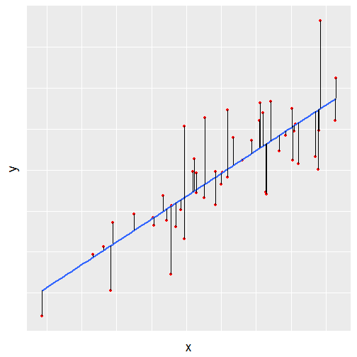

### Interpreting the parameters

When the model is \[ \boldsymbol{y} = \alpha + \beta_1 \boldsymbol{x}_1 + \beta_2 \boldsymbol{x}_2 + \boldsymbol{\epsilon} \]

- The main interest is to estimate the \( \boldsymbol{\beta} \) parameters
- Interpretation of an estimate \( \hat{\beta_1} = 2 \):
  - When \( x_1 \) increases by one unit, the average change in \( y \) is 2 units, given that the other variables (here \( x_2 \)) do not change.

### R linear model summary()

For a quick rundown of interpreting R's regression summary, see the 'Calling summary' section of [this blog post](http://blog.yhat.com/posts/r-lm-summary.html) or read about coefficients and p-values [here](http://blog.minitab.com/blog/adventures-in-statistics-2/regression-analysis-how-do-i-interpret-r-squared-and-assess-the-goodness-of-fit)

```
Call:
lm(formula = Y ~ some_variable)

Residuals:
    Min      1Q  Median      3Q     Max
-5.2528 -1.8261 -0.1636  1.5288  5.8723

Coefficients:
              Estimate Std. Error t value Pr(>|t|)
(Intercept)   -0.04364    0.49417  -0.088  0.93026
some_variable  1.81379    0.58925   3.078  0.00463 **
---
Signif. codes:  0 '***' 0.001 '**' 0.01 '*' 0.05 '.' 0.1 ' ' 1

Residual standard error: 2.643 on 28 degrees of freedom
Multiple R-squared:  0.2528,    Adjusted R-squared:  0.2262
F-statistic: 9.475 on 1 and 28 DF,  p-value: 0.004626
```

### Advanced example: Polynomial terms

The linearity assumption isn't as restrictive as one could imagine.

It is possible to add polynomial terms to the model if the effect of a variable is non-linear

\[ \boldsymbol{y} = \alpha + \beta_1 \cdot \boldsymbol{x} + \beta_2 \cdot \boldsymbol{x}^2 + \boldsymbol{\epsilon} \]

R:  
`lm(y ~ x + I(x^2))`

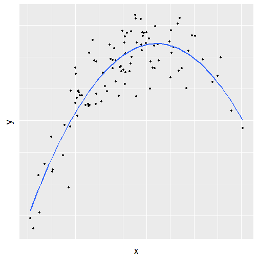

### Model validation

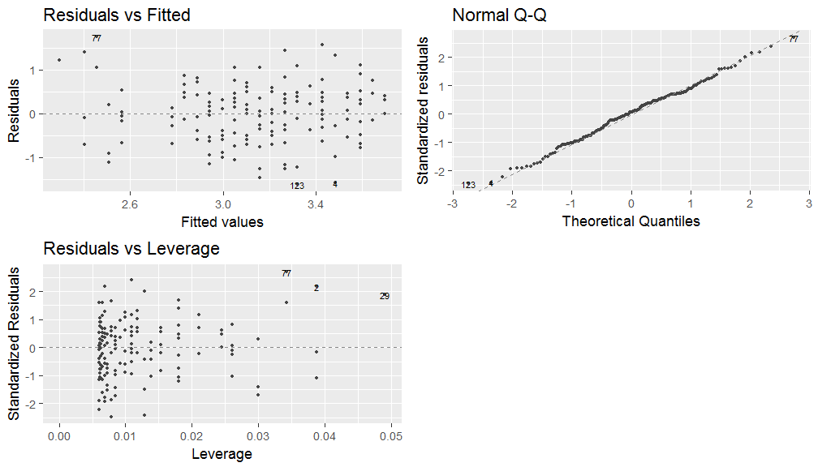

### Model assumptions

A statistical model always includes several assumptions which describe the data generating process.

- How well the model describes the phenomenom of interest, depends on how well the assumptions fit reality.
- In a linear regression model an obvious assumption is linearity: The target variable is modelled as a linear combination of the model parameters.
- Usually it is assumed that the errors are normally distributed.

### Assumptions of linear regression models

Analyzing the *residuals* of the model provides a method to explore the validity of the model assumptions. A lot of interesting assumptions are included in the expression

\[ \boldsymbol{\epsilon} \sim N(0, \sigma^2) \]

- The errors are normally distributed
- The errors are not correlated
- The errors have constant variance, \( \sigma^2 \)
- The size of a given error does not depend on the explanatory variables

### Normality of the errors (QQ-plot)

QQ-plot of the residuals provides a method to explore the assumption that the errors of the model are normally distributed

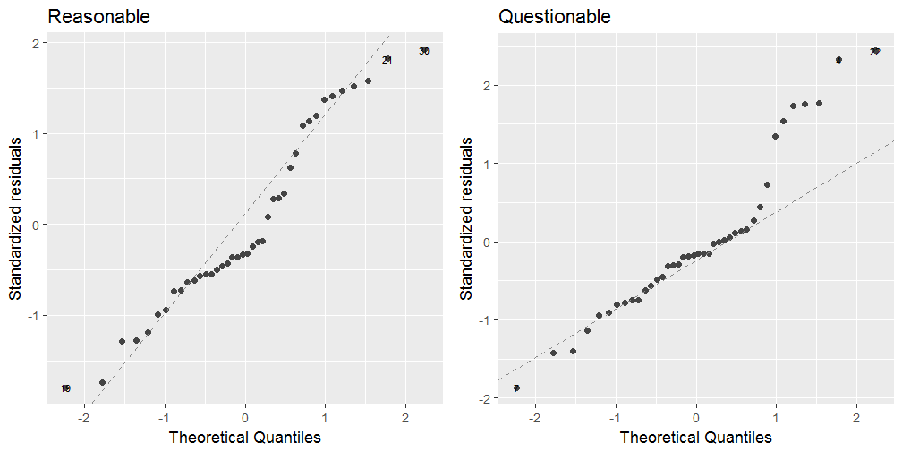

### Constant variance of errors

The constant variance assumption implies that the size of the errors should not depend on the explanatory variables.

This can be explored with a simple scatter plot of residuals versus model predictions.

**Any** patter in the scatter plot implies a problem with the assumptions

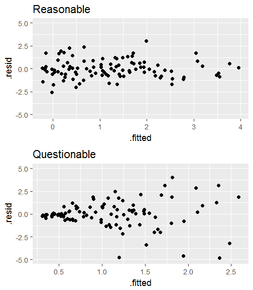

### Leverage of observations (1)

Leverage measures how much impact a single observation has on the model.

- Residuals vs leverage plot can help identify which observations have an unusually high impact.
- The next two slides show four examples.
- Each row of two plots defines a *data - model validation* pair.

### Leverage of observations (2)

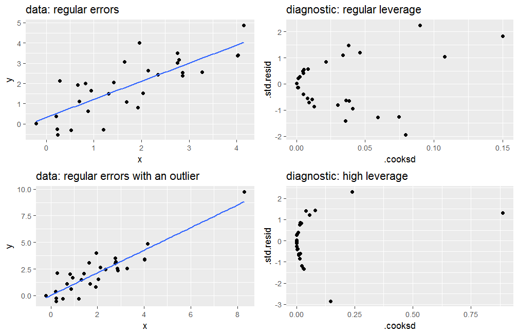

### Leverage of observations (3)

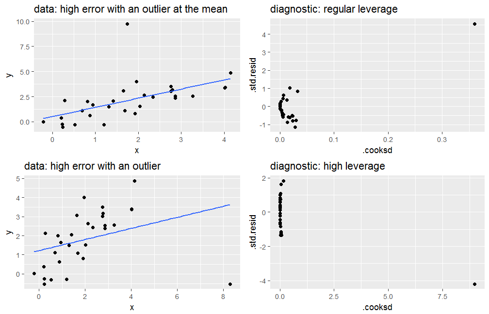

## Logistic regression and cross-validation

For IODS by Tuomo Nieminen

Powered by Rpresentation. The code for this presentation is [here.](https://raw.githubusercontent.com/TuomoNieminen/Helsinki-Open-Data-Science/master/docs/logistic_regression.Rpres)

### Logistic regression

Odds and probability

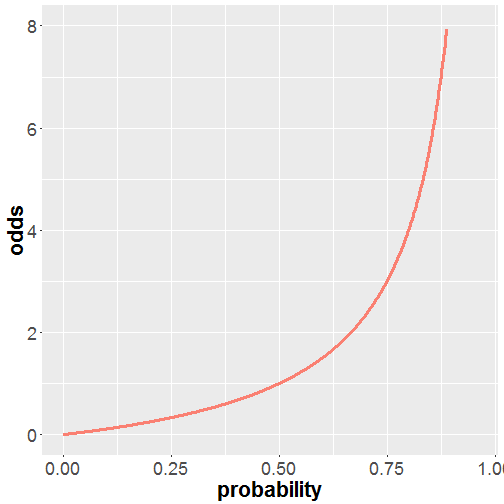

Predicting binary outcomes

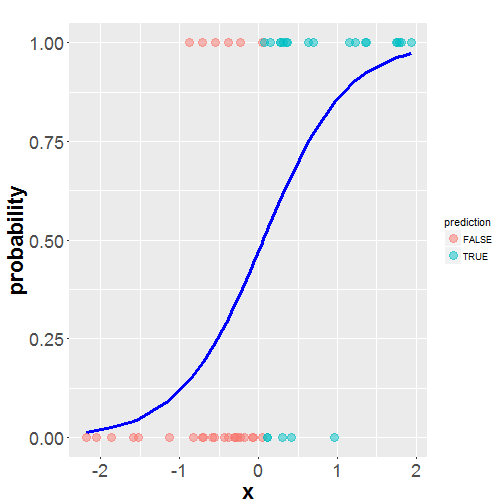

### A conditional look at regression

In regression analysis, the target variable \( \boldsymbol{Y} \) is modelled as a linear combination of the model parameters and the explanatory variables \( \boldsymbol{X} \)

\[ \boldsymbol{Y} = \boldsymbol{\alpha} + \boldsymbol{X}\boldsymbol{\beta} + \boldsymbol{\epsilon} \]

Another way to express this is to use *conditional expectation*

\[ E[\boldsymbol{Y} \mid \boldsymbol{X}] = \boldsymbol{\alpha} + \boldsymbol{X}\boldsymbol{\beta} \]

So, linear regression is a model for the (conditional) expected value of Y.

### Regression for binary outcomes

If the target variable \( Y \) is *binary*, taking only the values

- 0 (“failure”)
- 1 (“success”)

with probability \( p \), then \( E[Y] = p \).

- **The goal** in logistic regression is to define a linear model for the probability of “success” (\( p \), the expected value of \( Y \))
- The problem is that \( p \) only takes on values between 0 and 1
- A possible predictor can take on any value. There is no way to use multiplication and addition to restrict the predictors values to the range of \( p \). What to do?

### Odds

The ratio of expected “successes” to “failures” are called the odds:

\[ \frac{p}{1-p} \]

- Odds are an alternative way of expressing probabilities
- Higher odds corresponds to a higher probability of success
- The value of odds ranges from zero to infinity

*Odds of 2 to 1: the probability of success is twice as likely as the probability of failure, when p = 2/3.*

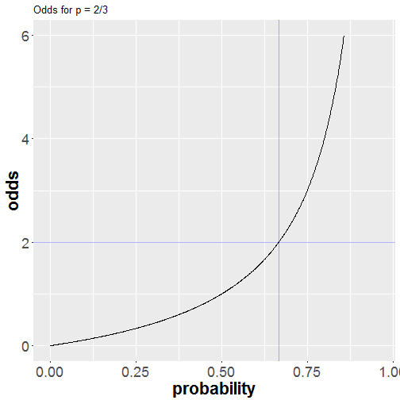

### The logit function

To transform \( p \) into a completely unrestricted scale, we can take the logarithm of odds:

\[ log\left( \frac{p}{1 - p} \right) \in [- \infty, \infty] \]

- The (natural) logarithm of odds is called the *logit function*.
- The possible values are all the real numbers (unrestricted).

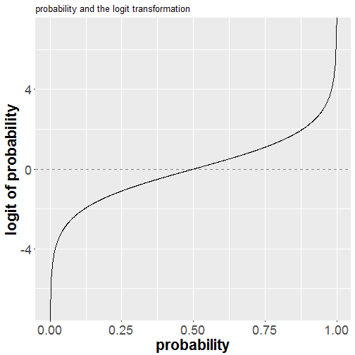

### Simple logistic regression

In a simple case, the logistic regression model for the expected value \( p \) of a binary variable \( Y \), is:

\[ log\left( \frac{p}{1 - p} \right) = \alpha + \beta \boldsymbol{x} + \boldsymbol{\epsilon} \]

which implies

\[ P(Y_i = 1) = \frac{1}{1 + e^{-\alpha - \beta \cdot x_i}} = p_i \]

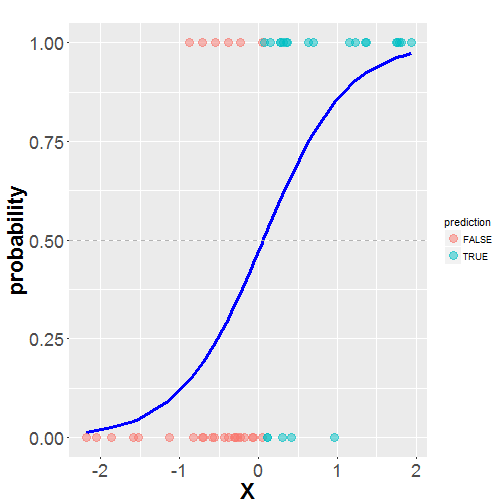

### Odds ratio

The ratio of two odds is called the odds ratio. It can be computed by the following steps:

1. Compute the odds of “success” (\( Y = 1 \)) for individuals who have the property \( X \).
2. Compute the odds of “success” (\( Y = 1 \)) for individuals who **do not** have property \( X \).
3. Divide the odds from step 1 by the odds from step 2 to obtain the odds ratio (OR).

Odds ratio can be used to quantify the relationship between \( X \) and \( Y \). Odds **higher than 1** mean that \( X \) is **positively associated** with “success”.

### Odds ratio example (1)

- *X = “has X”*
- *X_ = “doesn't have X”*
- *1 = “success”*
- *0 = “failure”*

toy data:

|  | X | X_ | total |
| --- | --- | --- | --- |
| 1 | 10 | 16 | 26 |
| 0 | 15 | 4 | 19 |
| total | 25 | 20 | 45 |

The following conditional probabilities can be calculated from the (toy) data:

- \( P(Y = 1 \mid X) = 10 / 25 = 0.4 \)
- \( P(Y = 0 \mid X) = 15 / 25 = 0.6 \)
- \( P(Y = 1 \mid X\_) = 16 / 20 = 0.8 \)
- \( P(Y = 0 \mid X\_) = 4 / 20 = 0.2 \)

### Odds ratio example (2)

Odds is the ratio of successes to failures:

- \( Odds(Y \mid X) = \frac{P(Y = 1 \mid X)}{P(Y = 0 \mid X)} = \frac{0.4}{0.6} = \frac{2}{3} \)
- \( Odds(Y \mid X\_) = \frac{P(Y = 1 \mid X\_)}{P(Y = 0 \mid X\_)} =\frac{0.8}{0.2} = 4 \)

Odds ratio (OR) is the ratio of the two odds:

\[ OR = \frac{Odds(Y \mid X)}{Odds(Y \mid X\_)} = \frac{2/3}{4} = \frac{1}{6} \]

toy data:

|  | X | X_ | total |
| --- | --- | --- | --- |
| 1 | 10 | 16 | 26 |
| 0 | 15 | 4 | 19 |
| total | 25 | 20 | 45 |

### Interpreting the parameters of logistic regression

From the fact that the computational target variable in the logistic regression model is the log of odds, it follows that applying the exponent function to the fitted values gives the odds:

\[ \exp \left( log\left( \frac{\hat{p}}{1 - \hat{p}} \right) \right) = \frac{\hat{p}}{1 - \hat{p}}. \]

The **exponents of the coefficients** can be interpret as **odds ratios** between a unit change (vs no change) in the corresponding explanatory variable.

\[ exp(\hat{\beta_x}) = Odds(Y \mid x + 1) / Odds(Y \mid x) \]

### Cross-validation

[figure not shown]

https://prateekvjoshi.files.wordpress.com/2013/06/cross-validation.png

### Training and testing sets

A statistical model can be used to make predictions. An intuitive way of comparing different models is to test their predictive power on unseen data.

- The available data can be split into training and testing sets
- Only the training data is used to find the model
- The testing data is then used to make predictions and evaluate the model performance

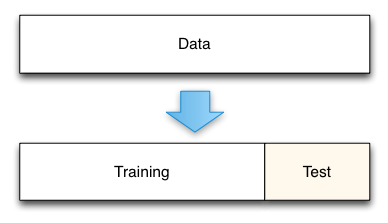

### Accuracy and error

In order to assert model performance, we need to measure it somehow.

- Depending on the nature of the target variable, different measures might make sense.
- If the task is *binary classification* such as in logistic regression, it is straight forward to calculate the proportion of correctly classified observations
- The proportion of incorrectly classified observations is the error (penalty, loss)

### Cross-validation (1)

Cross-validation is a powerful general technique for assessing how the results of a statistical analysis will generalize to an independent data set.

- Utilizes the idea of training and testing sets effectively
- Mainly used in settings where one wants to estimate how accurately a predictive model will perform in practice
- Gives a reasonable measure of performance on unseen data
- Can be used to compare different models to choose the best performing one

### Cross-validation (2)

One round of cross-validation involves

- Partitioning a sample of data into complementary subsets
- Performing the analysis on one subset (the training set, larger)
- Validating the analysis on the other subset (the testing set, smaller).

This process is repeated so that eventually all of the data is used for both training and testing.

### K-fold cross-validation

Below is an example of 5-fold cross-validation

[figure not shown]

The data is divided into subsets K times and eventually all the data is used for both training and testing.

## Clustering and classification

For IODS by Emma Kämäräinen

Powered by Rpresentation. The code for this presentation is [here.](https://raw.githubusercontent.com/TuomoNieminen/Helsinki-Open-Data-Science/master/docs/cluster_classification.Rpres)

### Clustering and classification

Classification:

- You know the classes
- The classification model is trained based on data
- Classify new observations

Clustering:

- Unknown classes / number of classes is unknown
- Find groups within data based on similarity of the observations

### Clustering and classification

- Linear discriminant analysis
- Distance measures
- K-means

### Linear discriminant analysis

Linear discriminant analysis (LDA) is a classification method. It can be used to model binary variables, like in logistic regression, or multiple class variables. The target variable needs to be categorical.

It can be used to

- Find the variables that discriminate/separate the classes best
- Predict the classes of new data
- Dimension reduction (not covered here)

[This](http://machinelearningmastery.com/linear-discriminant-analysis-for-machine-learning/) is a good and simple blog post about LDA. R-Bloggers also have a post about LDA, see it [here](https://www.r-bloggers.com/computing-and-visualizing-lda-in-r/).

### Linear discriminant analysis

Linear discriminant analysis produces results based on the assumptions that

- variables are normally distributed (on condition of the classes)
- the normal distributions for each class share the same covariance matrix

Because of the assumptions, the data might need scaling before fitting the model. The variables also need to be continuous.

Let's see an example next to wrap our heads around what LDA is really doing.

### LDA example

```
Call:
lda(Species ~ ., data = d)

Prior probabilities of groups:
    setosa versicolor  virginica
 0.3333333  0.3333333  0.3333333

Group means:
           Sepal.Length Sepal.Width Petal.Length Petal.Width
setosa       -1.0111914   0.8504137   -1.3006301  -1.2507035
versicolor    0.1119073  -0.6592236    0.2843712   0.1661774
virginica     0.8992841  -0.1911901    1.0162589   1.0845261

Coefficients of linear discriminants:
                    LD1         LD2
Sepal.Length  0.6867795  0.01995817
Sepal.Width   0.6688251  0.94344183
Petal.Length -3.8857950 -1.64511887
Petal.Width  -2.1422387  2.16413593

Proportion of trace:
   LD1    LD2
0.9912 0.0088
```

### LDA predictions

Classifying new observations:

- Based on the trained model LDA calculates the probabilities for the new observation for belonging in each of the classes
- The observation is classified to the class of the highest probability
- The math behind the probabilities can be seen [here](http://scikit-learn.org/stable/modules/lda_qda.html) for those who are interested. [Bayes theorem](https://en.wikipedia.org/wiki/Bayes'_theorem) is used to estimate the probabilities.
- You'll see how the predicting is done in the DataCamp exercises.

### LDA example

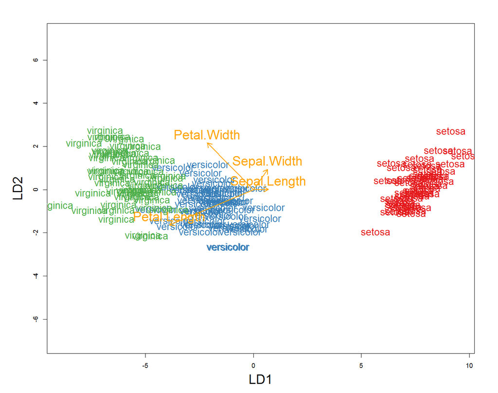

### Distance measures

How to determine if observations are similar or dissimilar with each others?

- [Euklidean distance](https://en.wikipedia.org/wiki/Euclidean_distance)
- [Manhattan/Taxicab distance](https://en.wikipedia.org/wiki/Taxicab_geometry) (axis-aligned directions)
- [Jaccard index](https://en.wikipedia.org/wiki/Jaccard_index) (binary/categorical distance measure)
- [Hamming distance](https://en.wikipedia.org/wiki/Hamming_distance) (distance measure for words/strings)

### K -means

- *K*-means is possibly the oldest and used clustering method in many fields of study
- Pro: Easy to use and often finds a solution
- Con: Small change in the dataset can produce very different results
- Many variations of *k*-means: *k*-means++, *k*-medoids, *k*-medians…

### K-means algorithm

1. Choose the number of clusters you want to have and pick initial cluster centroids.
2. Calculate distances between centroids and datapoints.
3. For all the data points: Assign data point to cluster based on which centroid is closest.
4. Update centroids: within each cluster, calculate new centroid
5. Update clusters: Calculate distances between data points and updated centroids. If some other centroid is closer than the cluster centroid where the data point belongs, the data point changes cluster.

Continue updating steps until the centroids or the clusters do not change

### K-means example

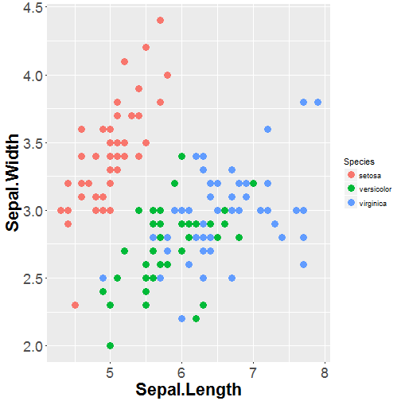

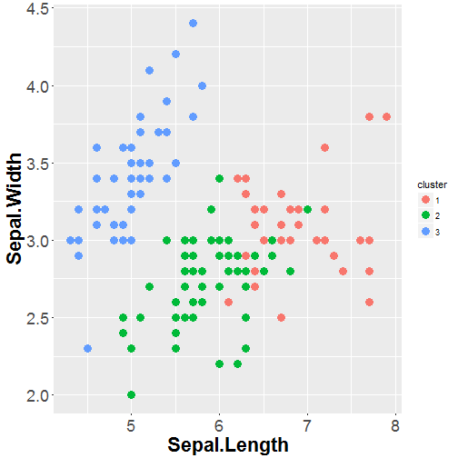

Source: [This R-Bloggers Post](https://www.r-bloggers.com/k-means-clustering-in-r/)

### K-means notes

Remarks about *k*-means:

- Distance measure in the algorithm:
  - Different distance measures produce different output
  - Deciding the best distance is not always easy
- Number of clusters as input
  - Many ways to find the optimal number of clusters
  - One way is to look at the total within cluster sum of squares (see next slide)
  - [Other ways](https://en.wikipedia.org/wiki/Determining_the_number_of_clusters_in_a_data_set): hierarchical clustering, silhouette method, cross validation …

### K-means: Total within sum of squares

Total within sum of squares is calculated by adding the within cluster sum of squares (WCSS) of every cluster together. The WCSS can be calculated with the pattern

\( WCSS = \sum_i^N (x_i - centroid)^2 \)

So you are searching for the number of clusters, where the observations are closest to the cluster center.

## Dimensionality Reduction Techniques

For IODS by Tuomo Nieminen & Emma Kämäräinen

Powered by Rpresentation. The code for this presentation is [here](https://raw.githubusercontent.com/TuomoNieminen/Helsinki-Open-Data-Science/master/docs/dimensionality_reduction.Rpres)

### Principal component analysis

From high…

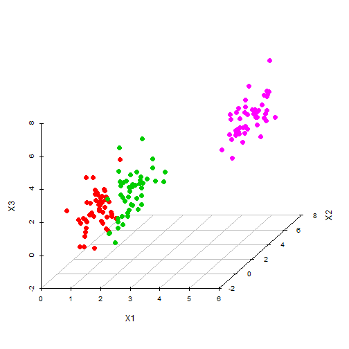

.. to lower dimensionality

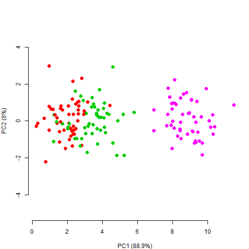

### What is dimensionality?

In statistical analysis, one can think of *dimensionality* as the number of variables (features) related to each observation in the data.

- If each observation is measured by \( d \) number of features, then the data is \( d \) dimensional. Each observation needs \( d \) points to define it's location in a **mathematical space**.
- If there are a lot of features, some of them can relate to the same underlying dimensions (not directly measured)
- Some dimensions may be stronger and some weaker, they are not equally important

### Dimensionality reduction

The original variables of high dimensional data might contain “too much” information (and noise or some other random error) for representing the underlying phenomenom of interest.

- A solution is to reduce the number of dimensions and focus only on the **most essential dimensions** extracted from the data
- In practise we can *transform* the data and use only a few **principal components** for visualisation and/or analysis
- Hope is that the variance along a small number of principal components provides a reasonable characterization of the complete data set

### Tools for dimensionality reduction

On the linear algebra level, Singular Value Decomposition (SVD) is the most important tool for reducing the number of dimensions in multivariate data.

- The SVD literally *decomposes* a matrix into a product of smaller matrices and reveals the most important components
- Principal Component Analysis (PCA) is a statistical procedure which does the same thing
- Correspondence Analysis (CA) or Multiple CA (MCA) can be used if the data consists of categorical variables
- The classification method LDA can also be considered as a dimensionality reduction technique

### Principal Component Analysis (PCA)

In PCA, the data is first *transformed* to a new space with equal or less number of dimensions (new features). These new features are called the **principal components**. They always have the following properties:

- The 1st principal component captures the maximum amount of variance from the features in the original data
- The 2nd principal component is orthogonal to the first and it captures the maximum amount of variability left
- The same is true for each principal component. They are all **uncorreleated** and each is less important than the previous one, in terms of captured variance.

### Reducing dimensionality with PCA

Given the properties of the principal components, we can simply choose the first few principal components to represent our data.

This will give us uncorrelated variables which capture the maximum amount of variation in the data!

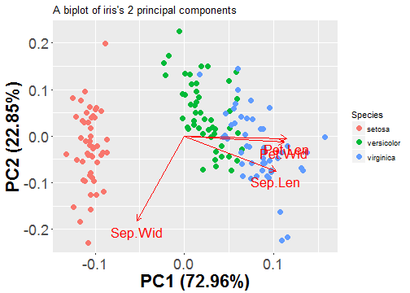

*The dimensionality of iris reduced to two principal components (PC). The first PC captures more than 70% of the total variance in the 4 original variables.*

### About PCA

Unlike LDA, PCA has no criteria or target variable. PCA may therefore be called an **unsupervised** method.

- PCA is sensitive to the relative scaling of the original features and assumes that features with larger variance are more important than features with smaller variance.
- **Standardization** of the features before PCA is often a good idea.
- PCA is powerful at encapsulating correlations between the original features into a smaller number of uncorrelated dimensions

### About PCA (2)

PCA is a mathematical tool, not a statistical model, which is why linear algebra (SVD) is enough.

- There is no statistical model for separating the sources of variance. All variance is thought to be from the same - although multidimensional - source.
- It is also possible to model the dimensionality using underlying latent variables with for example Factor Analysis
- These advanced methods of multivariate analysis are not part of this course

### Biplots

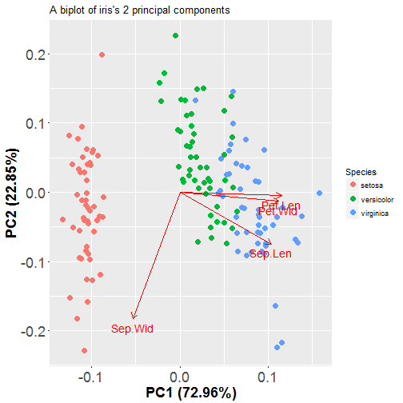

Correlations of iris

```
        Sep.Len Sep.Wid Pet.Len Pet.Wid
Sep.Len    1.00   -0.12    0.87    0.82
Sep.Wid   -0.12    1.00   -0.43   -0.37
Pet.Len    0.87   -0.43    1.00    0.96
Pet.Wid    0.82   -0.37    0.96    1.00
```

The correlations (and more) can be interpret from the biplot on the left, but how?

### The 'Bi' in Biplots

A biplot is a way of visualizing two representations of the same data. The biplot displays:

**(1)** The observations in a lower (2-)dimensional representation

- A scatter plot is drawn where the observations are placed on x and y coordinates defined by two principal components (PC's)

**(2)** The original features and their relationships with both each other and the principal components

- Arrows and/or labels are drawn to visualize the connections between the original features and the PC's.

### Properties of biplots

In a biplot, the following connections hold:

- The angle between arrows representing the original features can be interpret as the correlation between the features. Small angle = high positive correlation.
- The angle between a feature and a PC axis can be interpret as the correlation between the two. Small angle = high positive correlation.
- The length of the arrows are proportional to the standard deviations of the features

Biplots can be used to visualize the results of dimensionality reduction methods such as LDA, PCA, Correspondence Analysis (CA) and Multiple CA.

### Multiple Correspondence Analysis

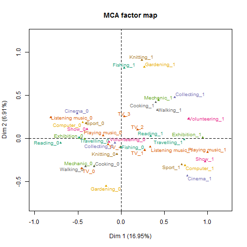

### Multiple Correspondence Analysis

- Dimensionality reduction method
- Analyses the pattern of relationships of several categorical variables
- Generalization of PCA and a extension of correspondence analysis (CA)
- Deals with categorical variables, but continuous ones can be used as background (supplementary) variables
- Can be used with qualitative data, so there are little assumptions about the variables or the data in general. MCA uses frequencies and you can count those even from text based datasets.

### Multiple Correspondence Analysis

- For the categorical variables, you can either use the [indicator matrix or the Burt matrix](https://en.wikipedia.org/wiki/Multiple_correspondence_analysis#As_an_extension_of_correspondences_analysis) in the analysis
  - The Indicator matrix contains all the levels of categorical variables as a binary variables (1 = belongs to category, 0 = if doesn't)
  - Burt matrix is a matrix of two-way cross-tabulations between all the variables in the dataset
- The general aim is to condense and present the information of the cross-tabulations in a clear graphical form
- Correspondence Analysis (a special case of MCA) works similarly with a cross-table of only two categorical variables
- There are also several other variations of the CA methods
- And next, let's look how the MCA outputs look in R!

### MCA summary(1)

Output of MCA summary contains…

- **Eigenvalues**: the variances and the percentage of variances retained by each dimension
- **Individuals**: the individuals coordinates, the individuals contribution (%) on the dimension and the cos2 (the squared correlations) on the dimensions.

```
Call:
MCA(X = data, graph = FALSE, method = "indicator")


Eigenvalues
                       Dim.1   Dim.2   Dim.3   Dim.4
Variance               0.413   0.334   0.330   0.256
% of var.             30.992  25.053  24.743  19.212
Cumulative % of var.  30.992  56.045  80.788 100.000

Individuals (the 3 first)
          Dim.1    ctr   cos2    Dim.2    ctr   cos2    Dim.3    ctr
1      |  0.283  0.065  0.056 | -0.283  0.080  0.056 | -0.534  0.288
2      |  1.055  0.898  0.802 | -0.431  0.185  0.134 | -0.209  0.044
3      |  0.138  0.015  0.035 | -0.048  0.002  0.004 | -0.103  0.011
         cos2
1       0.199 |
2       0.032 |
3       0.019 |

Categories (the 3 first)
           Dim.1     ctr    cos2  v.test     Dim.2     ctr    cos2  v.test
Label1 |   1.199  28.599   0.471  11.862 |  -0.786  15.197   0.202  -7.775
Label2 |  -0.569  16.801   0.584 -13.214 |  -0.121   0.935   0.026  -2.803
Label3 |   0.639   3.627   0.051   3.887 |   2.468  66.852   0.753  15.002
           Dim.3     ctr    cos2  v.test
Label1 |  -0.274   1.875   0.025  -2.714 |
Label2 |  -0.092   0.553   0.015  -2.142 |
Label3 |   1.154  14.813   0.165   7.018 |

Categorical variables (eta2)
         Dim.1 Dim.2 Dim.3
Var1   | 0.608 0.832 0.171 |
Var2   | 0.079 0.154 0.741 |
Var3   | 0.553 0.017 0.078 |
```

### MCA summary(2)

Output of MCA summary contains…

- **Categories**: the coordinates of the variable categories, the contribution (%), the cos2 (the squared correlations) and v.test value. The v.test follows normal distribution: if the value is below/above \( \pm \) 1.96, the coordinate is significantly different from zero.
- **Categorical variables**: the squared correlation between each variable and the dimensions. If the value is close to one it indicates a strong link with the variable and dimension.

```
Call:
MCA(X = data, graph = FALSE, method = "indicator")


Eigenvalues
                       Dim.1   Dim.2   Dim.3   Dim.4
Variance               0.413   0.334   0.330   0.256
% of var.             30.992  25.053  24.743  19.212
Cumulative % of var.  30.992  56.045  80.788 100.000

Individuals (the 3 first)
          Dim.1    ctr   cos2    Dim.2    ctr   cos2    Dim.3    ctr
1      |  0.283  0.065  0.056 | -0.283  0.080  0.056 | -0.534  0.288
2      |  1.055  0.898  0.802 | -0.431  0.185  0.134 | -0.209  0.044
3      |  0.138  0.015  0.035 | -0.048  0.002  0.004 | -0.103  0.011
         cos2
1       0.199 |
2       0.032 |
3       0.019 |

Categories (the 3 first)
           Dim.1     ctr    cos2  v.test     Dim.2     ctr    cos2  v.test
Label1 |   1.199  28.599   0.471  11.862 |  -0.786  15.197   0.202  -7.775
Label2 |  -0.569  16.801   0.584 -13.214 |  -0.121   0.935   0.026  -2.803
Label3 |   0.639   3.627   0.051   3.887 |   2.468  66.852   0.753  15.002
           Dim.3     ctr    cos2  v.test
Label1 |  -0.274   1.875   0.025  -2.714 |
Label2 |  -0.092   0.553   0.015  -2.142 |
Label3 |   1.154  14.813   0.165   7.018 |

Categorical variables (eta2)
         Dim.1 Dim.2 Dim.3
Var1   | 0.608 0.832 0.171 |
Var2   | 0.079 0.154 0.741 |
Var3   | 0.553 0.017 0.078 |
```

Read more from here and [here](http://factominer.free.fr/classical-methods/multiple-correspondence-analysis.html)

### MCA biplot(1)

Visualizing MCA:

- You can plot for variables, individuals and background (supplementary variables) separately or you can draw them in the same plot.
- `plot.MCA()` function in R (from FactoMineR) has a lot of options for plotting
- See a [video](https://www.youtube.com/watch?v=reG8Y9ZgcaQ) of MCA (plotting options start at 5:36).
- Let's look at a minimal example on the next slide.

### MCA biplot(2)

- On the right we have MCA factor map (biplot), where are variables drawn on the first two dimensions
  - The MCA biplot is a good visualization to see the possible variable patterns
  - The distance between variable categories gives a measure of their similarity
  - For example Label2 and Name2 are more similar than Label2 and Level2 and Label3 is different from all the other categories

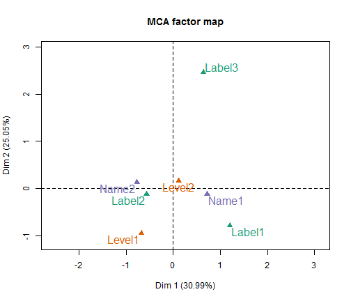

[figure not shown]